# Jupyter Notebook

- Interactive Python in a sharable document
  - Runs as a local web application
  - Like Mathematica notebooks
  - Alternatives: [Zeppelin](https://zeppelin.apache.org/), [Rodeo](https://rodeo.yhat.com/)
  - Extensions for Java, etc.: [BeakerX](http://beakerx.com/)
    - [Online Demo via Binder](https://mybinder.org/v2/gh/twosigma/beakerx/1.2.0?filepath=StartHere.ipynb)
  - Online Notebooks with Docker + JupyterHub: [Binder](https://mybinder.org/)
- It changed my life
  - Interactive plotting
  - Trial and error
  - Testing
  - Provenance (History)
  - Tutorials and teaching

# Basic Usage

- Type code in a cell
- Press shift-enter or press the "run" button
- Code is executed
- Last line is evaluated (shown as output)
- Order of execution, while creating, can be done out of order

```python
print("hello world")
```

```
hello world
```

```python
2 + 2
```

```
4
```

```python
x = 'foo'
```

```python
y = 'bar'
```

```python
x + y
```

```
'foobar'
```

# numpy

## fast numerical arrays in Python

```python
# an array of 1 to 63
import numpy

a = numpy.array([x for x in range(1, 64)], numpy.float64)
a
```

```
array([ 1.,  2.,  3.,  4.,  5.,  6.,  7.,  8.,  9., 10., 11., 12., 13.,
       14., 15., 16., 17., 18., 19., 20., 21., 22., 23., 24., 25., 26.,
       27., 28., 29., 30., 31., 32., 33., 34., 35., 36., 37., 38., 39.,
       40., 41., 42., 43., 44., 45., 46., 47., 48., 49., 50., 51., 52.,
       53., 54., 55., 56., 57., 58., 59., 60., 61., 62., 63.])
```

```python
# multiplying element-wise the 1 to 63 array (vectorized)
b = a * a
b
```

```
array([1.000e+00, 4.000e+00, 9.000e+00, 1.600e+01, 2.500e+01, 3.600e+01,
       4.900e+01, 6.400e+01, 8.100e+01, 1.000e+02, 1.210e+02, 1.440e+02,
       1.690e+02, 1.960e+02, 2.250e+02, 2.560e+02, 2.890e+02, 3.240e+02,
       3.610e+02, 4.000e+02, 4.410e+02, 4.840e+02, 5.290e+02, 5.760e+02,
       6.250e+02, 6.760e+02, 7.290e+02, 7.840e+02, 8.410e+02, 9.000e+02,
       9.610e+02, 1.024e+03, 1.089e+03, 1.156e+03, 1.225e+03, 1.296e+03,
       1.369e+03, 1.444e+03, 1.521e+03, 1.600e+03, 1.681e+03, 1.764e+03,
       1.849e+03, 1.936e+03, 2.025e+03, 2.116e+03, 2.209e+03, 2.304e+03,
       2.401e+03, 2.500e+03, 2.601e+03, 2.704e+03, 2.809e+03, 2.916e+03,
       3.025e+03, 3.136e+03, 3.249e+03, 3.364e+03, 3.481e+03, 3.600e+03,
       3.721e+03, 3.844e+03, 3.969e+03])
```

# matplotlib

## easy plotting in python

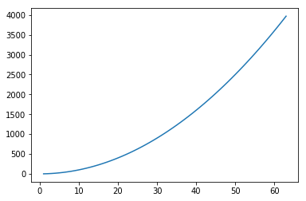

```python
# plotting a vs. b - where b = a * a
%matplotlib inline

import matplotlib.pyplot as plot

plot.plot(a, b)
plot.show()
```

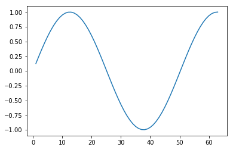

```python
# plot a sine wave
c = numpy.sin(a / 8)
plot.plot(a, c)
plot.show()
```

# scipy

## scientific and numerical algorithms

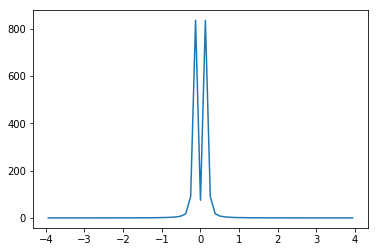

```python
# Fourier transform on our sine wave
from scipy import fftpack

transform = fftpack.fftshift(fftpack.fft(c))
frequencies = fftpack.fftshift(fftpack.fftfreq(c.size, d=1/8.0))

plot.plot(frequencies, numpy.abs(transform*transform))
plot.show()
```

# pandas

## tabular data (data frames)

### R calls these data frames, too

```python
# load a csv file as a data frame
import pandas

d = pandas.read_csv("mtcars.csv")
d
```

|  | name | mpg | cyl | disp | hp | drat | wt | qsec | vs | am | gear | carb |
| --- | --- | --- | --- | --- | --- | --- | --- | --- | --- | --- | --- | --- |
| 0 | Mazda RX4 | 21.0 | 6 | 160.0 | 110 | 3.90 | 2.620 | 16.46 | 0 | 1 | 4 | 4 |
| 1 | Mazda RX4 Wag | 21.0 | 6 | 160.0 | 110 | 3.90 | 2.875 | 17.02 | 0 | 1 | 4 | 4 |
| 2 | Datsun 710 | 22.8 | 4 | 108.0 | 93 | 3.85 | 2.320 | 18.61 | 1 | 1 | 4 | 1 |
| 3 | Hornet 4 Drive | 21.4 | 6 | 258.0 | 110 | 3.08 | 3.215 | 19.44 | 1 | 0 | 3 | 1 |
| 4 | Hornet Sportabout | 18.7 | 8 | 360.0 | 175 | 3.15 | 3.440 | 17.02 | 0 | 0 | 3 | 2 |
| 5 | Valiant | 18.1 | 6 | 225.0 | 105 | 2.76 | 3.460 | 20.22 | 1 | 0 | 3 | 1 |
| 6 | Duster 360 | 14.3 | 8 | 360.0 | 245 | 3.21 | 3.570 | 15.84 | 0 | 0 | 3 | 4 |
| 7 | Merc 240D | 24.4 | 4 | 146.7 | 62 | 3.69 | 3.190 | 20.00 | 1 | 0 | 4 | 2 |
| 8 | Merc 230 | 22.8 | 4 | 140.8 | 95 | 3.92 | 3.150 | 22.90 | 1 | 0 | 4 | 2 |
| 9 | Merc 280 | 19.2 | 6 | 167.6 | 123 | 3.92 | 3.440 | 18.30 | 1 | 0 | 4 | 4 |
| 10 | Merc 280C | 17.8 | 6 | 167.6 | 123 | 3.92 | 3.440 | 18.90 | 1 | 0 | 4 | 4 |
| 11 | Merc 450SE | 16.4 | 8 | 275.8 | 180 | 3.07 | 4.070 | 17.40 | 0 | 0 | 3 | 3 |
| 12 | Merc 450SL | 17.3 | 8 | 275.8 | 180 | 3.07 | 3.730 | 17.60 | 0 | 0 | 3 | 3 |
| 13 | Merc 450SLC | 15.2 | 8 | 275.8 | 180 | 3.07 | 3.780 | 18.00 | 0 | 0 | 3 | 3 |
| 14 | Cadillac Fleetwood | 10.4 | 8 | 472.0 | 205 | 2.93 | 5.250 | 17.98 | 0 | 0 | 3 | 4 |
| 15 | Lincoln Continental | 10.4 | 8 | 460.0 | 215 | 3.00 | 5.424 | 17.82 | 0 | 0 | 3 | 4 |
| 16 | Chrysler Imperial | 14.7 | 8 | 440.0 | 230 | 3.23 | 5.345 | 17.42 | 0 | 0 | 3 | 4 |
| 17 | Fiat 128 | 32.4 | 4 | 78.7 | 66 | 4.08 | 2.200 | 19.47 | 1 | 1 | 4 | 1 |
| 18 | Honda Civic | 30.4 | 4 | 75.7 | 52 | 4.93 | 1.615 | 18.52 | 1 | 1 | 4 | 2 |
| 19 | Toyota Corolla | 33.9 | 4 | 71.1 | 65 | 4.22 | 1.835 | 19.90 | 1 | 1 | 4 | 1 |
| 20 | Toyota Corona | 21.5 | 4 | 120.1 | 97 | 3.70 | 2.465 | 20.01 | 1 | 0 | 3 | 1 |
| 21 | Dodge Challenger | 15.5 | 8 | 318.0 | 150 | 2.76 | 3.520 | 16.87 | 0 | 0 | 3 | 2 |
| 22 | AMC Javelin | 15.2 | 8 | 304.0 | 150 | 3.15 | 3.435 | 17.30 | 0 | 0 | 3 | 2 |
| 23 | Camaro Z28 | 13.3 | 8 | 350.0 | 245 | 3.73 | 3.840 | 15.41 | 0 | 0 | 3 | 4 |
| 24 | Pontiac Firebird | 19.2 | 8 | 400.0 | 175 | 3.08 | 3.845 | 17.05 | 0 | 0 | 3 | 2 |
| 25 | Fiat X1-9 | 27.3 | 4 | 79.0 | 66 | 4.08 | 1.935 | 18.90 | 1 | 1 | 4 | 1 |
| 26 | Porsche 914-2 | 26.0 | 4 | 120.3 | 91 | 4.43 | 2.140 | 16.70 | 0 | 1 | 5 | 2 |
| 27 | Lotus Europa | 30.4 | 4 | 95.1 | 113 | 3.77 | 1.513 | 16.90 | 1 | 1 | 5 | 2 |
| 28 | Ford Pantera L | 15.8 | 8 | 351.0 | 264 | 4.22 | 3.170 | 14.50 | 0 | 1 | 5 | 4 |
| 29 | Ferrari Dino | 19.7 | 6 | 145.0 | 175 | 3.62 | 2.770 | 15.50 | 0 | 1 | 5 | 6 |
| 30 | Maserati Bora | 15.0 | 8 | 301.0 | 335 | 3.54 | 3.570 | 14.60 | 0 | 1 | 5 | 8 |
| 31 | Volvo 142E | 21.4 | 4 | 121.0 | 109 | 4.11 | 2.780 | 18.60 | 1 | 1 | 4 | 2 |

```python
# pick rows 5-9 (slicing)
d[5:10]
```

|  | name | mpg | cyl | disp | hp | drat | wt | qsec | vs | am | gear | carb |
| --- | --- | --- | --- | --- | --- | --- | --- | --- | --- | --- | --- | --- |
| 5 | Valiant | 18.1 | 6 | 225.0 | 105 | 2.76 | 3.46 | 20.22 | 1 | 0 | 3 | 1 |
| 6 | Duster 360 | 14.3 | 8 | 360.0 | 245 | 3.21 | 3.57 | 15.84 | 0 | 0 | 3 | 4 |
| 7 | Merc 240D | 24.4 | 4 | 146.7 | 62 | 3.69 | 3.19 | 20.00 | 1 | 0 | 4 | 2 |
| 8 | Merc 230 | 22.8 | 4 | 140.8 | 95 | 3.92 | 3.15 | 22.90 | 1 | 0 | 4 | 2 |
| 9 | Merc 280 | 19.2 | 6 | 167.6 | 123 | 3.92 | 3.44 | 18.30 | 1 | 0 | 4 | 4 |

```python
# pick columns 'cyl' and 'disp'
d[['cyl', 'disp']]
```

|  | cyl | disp |
| --- | --- | --- |
| 0 | 6 | 160.0 |
| 1 | 6 | 160.0 |
| 2 | 4 | 108.0 |
| 3 | 6 | 258.0 |
| 4 | 8 | 360.0 |
| 5 | 6 | 225.0 |
| 6 | 8 | 360.0 |
| 7 | 4 | 146.7 |
| 8 | 4 | 140.8 |
| 9 | 6 | 167.6 |
| 10 | 6 | 167.6 |
| 11 | 8 | 275.8 |
| 12 | 8 | 275.8 |
| 13 | 8 | 275.8 |
| 14 | 8 | 472.0 |
| 15 | 8 | 460.0 |
| 16 | 8 | 440.0 |
| 17 | 4 | 78.7 |
| 18 | 4 | 75.7 |
| 19 | 4 | 71.1 |
| 20 | 4 | 120.1 |
| 21 | 8 | 318.0 |
| 22 | 8 | 304.0 |
| 23 | 8 | 350.0 |
| 24 | 8 | 400.0 |
| 25 | 4 | 79.0 |
| 26 | 4 | 120.3 |
| 27 | 4 | 95.1 |
| 28 | 8 | 351.0 |
| 29 | 6 | 145.0 |
| 30 | 8 | 301.0 |
| 31 | 4 | 121.0 |

```python
# picking rows 5:9 and columns 'cyl' and 'disp'
d[['cyl', 'disp']][5:10]
```

|  | cyl | disp |
| --- | --- | --- |
| 5 | 6 | 225.0 |
| 6 | 8 | 360.0 |
| 7 | 4 | 146.7 |
| 8 | 4 | 140.8 |
| 9 | 6 | 167.6 |

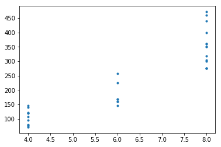

```python
# plotting columns 'cyl' vs 'disp'
plot.plot(d[['cyl']], d[['disp']], '.')
```

```python
# select the cars that have greater than 200 horsepower and 4 gears
d[(d['hp'] > 200) & (d['gear'] > 4)]
```

|  | name | mpg | cyl | disp | hp | drat | wt | qsec | vs | am | gear | carb |
| --- | --- | --- | --- | --- | --- | --- | --- | --- | --- | --- | --- | --- |
| 28 | Ford Pantera L | 15.8 | 8 | 351.0 | 264 | 4.22 | 3.17 | 14.5 | 0 | 1 | 5 | 4 |
| 30 | Maserati Bora | 15.0 | 8 | 301.0 | 335 | 3.54 | 3.57 | 14.6 | 0 | 1 | 5 | 8 |

```python
# select the cards that have less than 6 cylinders or less than 4 gears
d[(d['cyl'] < 6) | (d['gear'] < 4)]
```

|  | name | mpg | cyl | disp | hp | drat | wt | qsec | vs | am | gear | carb |
| --- | --- | --- | --- | --- | --- | --- | --- | --- | --- | --- | --- | --- |
| 2 | Datsun 710 | 22.8 | 4 | 108.0 | 93 | 3.85 | 2.320 | 18.61 | 1 | 1 | 4 | 1 |
| 3 | Hornet 4 Drive | 21.4 | 6 | 258.0 | 110 | 3.08 | 3.215 | 19.44 | 1 | 0 | 3 | 1 |
| 4 | Hornet Sportabout | 18.7 | 8 | 360.0 | 175 | 3.15 | 3.440 | 17.02 | 0 | 0 | 3 | 2 |
| 5 | Valiant | 18.1 | 6 | 225.0 | 105 | 2.76 | 3.460 | 20.22 | 1 | 0 | 3 | 1 |
| 6 | Duster 360 | 14.3 | 8 | 360.0 | 245 | 3.21 | 3.570 | 15.84 | 0 | 0 | 3 | 4 |
| 7 | Merc 240D | 24.4 | 4 | 146.7 | 62 | 3.69 | 3.190 | 20.00 | 1 | 0 | 4 | 2 |
| 8 | Merc 230 | 22.8 | 4 | 140.8 | 95 | 3.92 | 3.150 | 22.90 | 1 | 0 | 4 | 2 |
| 11 | Merc 450SE | 16.4 | 8 | 275.8 | 180 | 3.07 | 4.070 | 17.40 | 0 | 0 | 3 | 3 |
| 12 | Merc 450SL | 17.3 | 8 | 275.8 | 180 | 3.07 | 3.730 | 17.60 | 0 | 0 | 3 | 3 |
| 13 | Merc 450SLC | 15.2 | 8 | 275.8 | 180 | 3.07 | 3.780 | 18.00 | 0 | 0 | 3 | 3 |
| 14 | Cadillac Fleetwood | 10.4 | 8 | 472.0 | 205 | 2.93 | 5.250 | 17.98 | 0 | 0 | 3 | 4 |
| 15 | Lincoln Continental | 10.4 | 8 | 460.0 | 215 | 3.00 | 5.424 | 17.82 | 0 | 0 | 3 | 4 |
| 16 | Chrysler Imperial | 14.7 | 8 | 440.0 | 230 | 3.23 | 5.345 | 17.42 | 0 | 0 | 3 | 4 |
| 17 | Fiat 128 | 32.4 | 4 | 78.7 | 66 | 4.08 | 2.200 | 19.47 | 1 | 1 | 4 | 1 |
| 18 | Honda Civic | 30.4 | 4 | 75.7 | 52 | 4.93 | 1.615 | 18.52 | 1 | 1 | 4 | 2 |
| 19 | Toyota Corolla | 33.9 | 4 | 71.1 | 65 | 4.22 | 1.835 | 19.90 | 1 | 1 | 4 | 1 |
| 20 | Toyota Corona | 21.5 | 4 | 120.1 | 97 | 3.70 | 2.465 | 20.01 | 1 | 0 | 3 | 1 |
| 21 | Dodge Challenger | 15.5 | 8 | 318.0 | 150 | 2.76 | 3.520 | 16.87 | 0 | 0 | 3 | 2 |
| 22 | AMC Javelin | 15.2 | 8 | 304.0 | 150 | 3.15 | 3.435 | 17.30 | 0 | 0 | 3 | 2 |
| 23 | Camaro Z28 | 13.3 | 8 | 350.0 | 245 | 3.73 | 3.840 | 15.41 | 0 | 0 | 3 | 4 |
| 24 | Pontiac Firebird | 19.2 | 8 | 400.0 | 175 | 3.08 | 3.845 | 17.05 | 0 | 0 | 3 | 2 |
| 25 | Fiat X1-9 | 27.3 | 4 | 79.0 | 66 | 4.08 | 1.935 | 18.90 | 1 | 1 | 4 | 1 |
| 26 | Porsche 914-2 | 26.0 | 4 | 120.3 | 91 | 4.43 | 2.140 | 16.70 | 0 | 1 | 5 | 2 |
| 27 | Lotus Europa | 30.4 | 4 | 95.1 | 113 | 3.77 | 1.513 | 16.90 | 1 | 1 | 5 | 2 |
| 31 | Volvo 142E | 21.4 | 4 | 121.0 | 109 | 4.11 | 2.780 | 18.60 | 1 | 1 | 4 | 2 |

```python
# get the cars with 4 or less gears, only name, horsepower, and displacement, sorted by horsepower
q = d[['name', 'hp', 'disp']][d['gear'] < 4].sort_values('hp')
q
```

|  | name | hp | disp |
| --- | --- | --- | --- |
| 20 | Toyota Corona | 97 | 120.1 |
| 5 | Valiant | 105 | 225.0 |
| 3 | Hornet 4 Drive | 110 | 258.0 |
| 21 | Dodge Challenger | 150 | 318.0 |
| 22 | AMC Javelin | 150 | 304.0 |
| 4 | Hornet Sportabout | 175 | 360.0 |
| 24 | Pontiac Firebird | 175 | 400.0 |
| 11 | Merc 450SE | 180 | 275.8 |
| 12 | Merc 450SL | 180 | 275.8 |
| 13 | Merc 450SLC | 180 | 275.8 |
| 14 | Cadillac Fleetwood | 205 | 472.0 |
| 15 | Lincoln Continental | 215 | 460.0 |
| 16 | Chrysler Imperial | 230 | 440.0 |
| 6 | Duster 360 | 245 | 360.0 |
| 23 | Camaro Z28 | 245 | 350.0 |

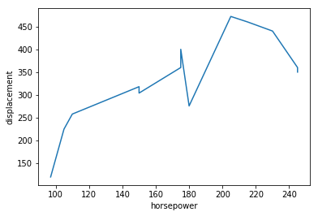

```python
# plot the previous data of horsepower vs. displacement
plot.plot(q['hp'], q['disp'])
plot.xlabel('horsepower')
plot.ylabel('displacement')
plot.show()
```

# Matplotlib can do a lot more

https://matplotlib.org/tutorials/introductory/sample_plots.html

- Contour plots
- Bar charts
- Histograms
- 3D plotting
- Streamlines
- Glyphs
- Pie charts
- Mixed scatterplot/line charts
- Plots in the style of XKCD

# I don't actually use Pandas

- Pandas is very popular, but I don't like it
  - I thought I would give it due credit
- But, data frame syntax is *terrible*
  - And it's in memory only, though there's Dask
- And, data frame syntax is *terrible*
- What should you use instead?
  - A real relational database, like SQLite
- Did I mention that data frame syntax is *terrible*

# Why you should use SQLite

- Open source
- The SQL skills you learn translate to other databases
  - Years of database optimization research
  - SQL queries created in Python directly translate to R
  - If you use "virtual tables" you can query *any* data set with SQL, including file systems and text files
- You learn:
  - Relational data concepts, including joins
  - Data parallelism concepts
  - Map-reduce concepts
  - Functional programming concepts
- It is a universal data storage format
  - It runs everywhere, including smartphones
  - Doesn't require a database server, it is a single file
- Can use data larger than memory
  - Easily handles gigabytes of data
- See my talk on "One Reader to Rule them All"
  - https://github.com/jonwoodring/ortrta

# Small note on scientific data storage

- It wildly varies between disciplines
  - Many custom formats
- Common ones
  - HDF5
  - NetCDF
  - raw binary
  - ASCII or CSV
- Start ParaView and look at the number of readers supported
- It's always a problem in visualizing and analyzing data
  - First thing I have to ask: "How do I read your data?"
- Storage I/O is almost always the slowest thing (bottleneck) on your computer

```python
# copy our csv file into an in memory SQLite database
import sqlite3
import csv

# the in memory database connection
# if you change ':memory:' to a filename, it
conn = sqlite3.Connection(':memory:')
cursor = conn.cursor()

# just a bit of code to parse the csv and insert it into a database
f = csv.reader(open('mtcars.csv'))
# read the first line to get the column names
names = next(f)
qs = '?,' * len(names)
qs = qs[:-1]
cursor.execute('DROP table IF EXISTS mtcars')
# read the first data line to determine data types
first = next(f)
types = []
for col in first:
    t = 'text'
    try:
        v = int(col)
        t = 'integer'
    except Exception as e:
        try:
            v = float(col)
            t = 'real'
        except Exception as e:
            pass
    types.append(t)
columns = ''
for n, t in zip(names, types):
    columns = columns + n + ' ' + t + ', '
columns = columns[:-2]
# create the table
table = 'CREATE TABLE mtcars (%s)' % columns
print(table)
cursor.execute(table)
# insert the data
cursor.execute('INSERT INTO mtcars VALUES (%s)' % qs, first)
for row in f:
    cursor.execute('INSERT INTO mtcars VALUES (%s)' % qs, row)
conn.commit()
```

```
CREATE TABLE mtcars (name text, mpg integer, cyl integer, disp integer, hp integer, drat real, wt real, qsec real, vs integer, am integer, gear integer, carb integer)
```

```python
# select all columns from mtcars (and all rows)
cursor.execute('SELECT * FROM mtcars').fetchall()
```

```
[('Mazda RX4', 21, 6, 160, 110, 3.9, 2.62, 16.46, 0, 1, 4, 4),
 ('Mazda RX4 Wag', 21, 6, 160, 110, 3.9, 2.875, 17.02, 0, 1, 4, 4),
 ('Datsun 710', 22.8, 4, 108, 93, 3.85, 2.32, 18.61, 1, 1, 4, 1),
 ('Hornet 4 Drive', 21.4, 6, 258, 110, 3.08, 3.215, 19.44, 1, 0, 3, 1),
 ('Hornet Sportabout', 18.7, 8, 360, 175, 3.15, 3.44, 17.02, 0, 0, 3, 2),
 ('Valiant', 18.1, 6, 225, 105, 2.76, 3.46, 20.22, 1, 0, 3, 1),
 ('Duster 360', 14.3, 8, 360, 245, 3.21, 3.57, 15.84, 0, 0, 3, 4),
 ('Merc 240D', 24.4, 4, 146.7, 62, 3.69, 3.19, 20.0, 1, 0, 4, 2),
 ('Merc 230', 22.8, 4, 140.8, 95, 3.92, 3.15, 22.9, 1, 0, 4, 2),
 ('Merc 280', 19.2, 6, 167.6, 123, 3.92, 3.44, 18.3, 1, 0, 4, 4),
 ('Merc 280C', 17.8, 6, 167.6, 123, 3.92, 3.44, 18.9, 1, 0, 4, 4),
 ('Merc 450SE', 16.4, 8, 275.8, 180, 3.07, 4.07, 17.4, 0, 0, 3, 3),
 ('Merc 450SL', 17.3, 8, 275.8, 180, 3.07, 3.73, 17.6, 0, 0, 3, 3),
 ('Merc 450SLC', 15.2, 8, 275.8, 180, 3.07, 3.78, 18.0, 0, 0, 3, 3),
 ('Cadillac Fleetwood', 10.4, 8, 472, 205, 2.93, 5.25, 17.98, 0, 0, 3, 4),
 ('Lincoln Continental', 10.4, 8, 460, 215, 3.0, 5.424, 17.82, 0, 0, 3, 4),
 ('Chrysler Imperial', 14.7, 8, 440, 230, 3.23, 5.345, 17.42, 0, 0, 3, 4),
 ('Fiat 128', 32.4, 4, 78.7, 66, 4.08, 2.2, 19.47, 1, 1, 4, 1),
 ('Honda Civic', 30.4, 4, 75.7, 52, 4.93, 1.615, 18.52, 1, 1, 4, 2),
 ('Toyota Corolla', 33.9, 4, 71.1, 65, 4.22, 1.835, 19.9, 1, 1, 4, 1),
 ('Toyota Corona', 21.5, 4, 120.1, 97, 3.7, 2.465, 20.01, 1, 0, 3, 1),
 ('Dodge Challenger', 15.5, 8, 318, 150, 2.76, 3.52, 16.87, 0, 0, 3, 2),
 ('AMC Javelin', 15.2, 8, 304, 150, 3.15, 3.435, 17.3, 0, 0, 3, 2),
 ('Camaro Z28', 13.3, 8, 350, 245, 3.73, 3.84, 15.41, 0, 0, 3, 4),
 ('Pontiac Firebird', 19.2, 8, 400, 175, 3.08, 3.845, 17.05, 0, 0, 3, 2),
 ('Fiat X1-9', 27.3, 4, 79, 66, 4.08, 1.935, 18.9, 1, 1, 4, 1),
 ('Porsche 914-2', 26, 4, 120.3, 91, 4.43, 2.14, 16.7, 0, 1, 5, 2),
 ('Lotus Europa', 30.4, 4, 95.1, 113, 3.77, 1.513, 16.9, 1, 1, 5, 2),
 ('Ford Pantera L', 15.8, 8, 351, 264, 4.22, 3.17, 14.5, 0, 1, 5, 4),
 ('Ferrari Dino', 19.7, 6, 145, 175, 3.62, 2.77, 15.5, 0, 1, 5, 6),
 ('Maserati Bora', 15, 8, 301, 335, 3.54, 3.57, 14.6, 0, 1, 5, 8),
 ('Volvo 142E', 21.4, 4, 121, 109, 4.11, 2.78, 18.6, 1, 1, 4, 2)]
```

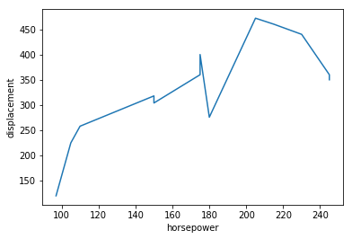

```python
# a little function to turn columns from a SQL query into Python lists, for plotting
def query_to_columns(query, cursor):
    cursor.execute(query)
    columns = [[x] for x in cursor.fetchone()]
    for row in cursor.fetchall():
        for col, column in zip(row, columns):
            column.append(col)
    return columns

# our query from before
# select columns name, hp, disp where the number of gears is less than 4, order by hp
name, hp, disp = query_to_columns('SELECT name, hp, disp FROM mtcars WHERE gear < 4 ORDER BY hp', cursor)
plot.plot(hp, disp)
plot.xlabel('horsepower')
plot.ylabel('displacement')
plot.show()
```

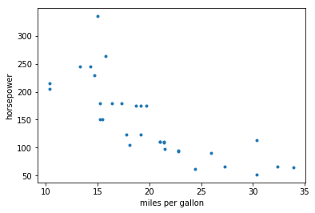

```python
# mpg vs. hp
mpg, hp = query_to_columns('SELECT mpg, hp FROM mtcars ORDER BY mpg', cursor)
plot.plot(mpg, hp, '.')
plot.xlabel('miles per gallon')
plot.ylabel('horsepower')
plot.show()
```

# adding color and legends

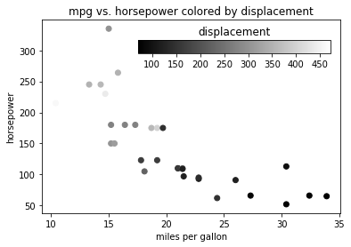

```python
# get our data to plot
mpg, hp, disp = query_to_columns('SELECT mpg, hp, disp FROM mtcars ORDER BY mpg', cursor)

# multiple items require a figure
fig = plot.figure()
axes = fig.add_subplot('111')

# scatterplot
im = axes.scatter(mpg, hp, c=disp, cmap=plot.get_cmap('gist_gray'))
axes.set_title('mpg vs. horsepower colored by displacement')
axes.set_xlabel('miles per gallon')
axes.set_ylabel('horsepower')

# color bar
cax = fig.add_axes([0.375, 0.75, 0.5, 0.05]) # position
from matplotlib.colors import Normalize
cb = plot.colorbar(im, cax, cmap=plot.get_cmap('gist_gray'), # colors
                   norm=Normalize(vmin=min(disp), vmax=max(disp)), orientation='horizontal')
cax.set_title('displacement') # title

plot.show()
```

# Bokeh

## interactively plot data from Python

```python
from bokeh.resources import INLINE # INLINE allows it to be embedded without a CDN
from bokeh.plotting import figure, show
from bokeh.io import output_notebook
from bokeh.layouts import gridplot
from bokeh.models import ColumnDataSource

# output to notebook (INLINE embeds Bokeh into HTML to work without network)
output_notebook(INLINE)

# get the data from the database
name, mpg, disp, hp, cyl = query_to_columns('SELECT name, mpg, disp, hp, cyl FROM mtcars', cursor)

# for Bokeh interactivity and linking, data needs to go into a data source
data = ColumnDataSource({'name': name, 'mpg': mpg, 'disp': disp, 'hp': hp, 'cyl': cyl})

# tooltips configure
tips = [
    ('name', '@name'),
    ('mpg', '@mpg'),
    ('hp', '@hp'),
    ('disp', '@disp'),
    ('cyl', '@cyl')
]

# figure one
f = figure(title='mpg vs. displacement', tooltips=tips,
           tools="box_select,box_zoom,lasso_select,reset,hover",
           width=400, height=400)
f.circle(x='mpg', y='disp', size=10, source=data)
f.xaxis.axis_label = 'miles per gallon'
f.yaxis.axis_label = 'displacement'

# figure two
g = figure(title='horsepower vs. cylinders', tooltips=tips,
           tools="box_select,box_zoom,lasso_select,reset,hover",
           width=400, height=400)
g.circle(x='hp', y='cyl', size=10, source=data)
g.xaxis.axis_label = 'horsepower'
g.yaxis.axis_label = 'cylinders'

# selections will be linked due to sharing the data source
grid = gridplot([[f, g]])
show(grid)
```

[interactive chart not shown]

# Bokeh to Web

- Bokeh can be used to generate web deployable visualizations
  - A Jupyter Notebook can be saved as HTML, like these slides
  - This is similar to R Shiny
- For small data, save notebook as HTML
  - You can embed the data directly in the Javascript
- For big data, Bokeh Server
  - Interactive web apps that serve up data to the Javascript/HTML
  - Similar to the commercial solutions found in Tableau

# Coupling Python to HTML/JavaScript (Advanced)

- For Bokeh, the data from Python is being injected into the HTML
  - Then, BokehJS (Javascript) is plotting the HTML data
  - BokehJS is a library that can be used separately from Bokeh Python
- Knowing this, you can use *any* Javascript plotting package, in a Jupyter notebook
  - Jupyter Python has "magic" %%javascript command
  - With a little bit of programming, you can inject data from a Python cell into the browser
  - Then, use require.js or modules. to load D3, Charts.js, etc. to plot the data
- You can create many custom visualizations that are web deployable using Jupyter as a starting point, without having to rely on Bokeh
  - Examples: WebGL, D3, Vega, Charts.js, etc.
- Look into Bokeh, BokehJS, and Jupyter developer documentation and source code
  - Open source, go do it!